# Visualising Networks with ggraph

### Visualisation with ggraph

The last step in the workflow is visualising the network. You can use igraph and standard R plotting libraries for this, but I use a package called ggraph, which uses the same language as ggplot (a very well-known visualisation library for R) and adds some special functions to visualise networks. To create a network diagram, first use the function `ggraph` on your tbl_graph, then add the special [ggraph geoms](https://ggplot2.tidyverse.org/reference/) `geom_node_point()` and `geom_edge_link()`

```r
library(tidygraph)
library(tidyverse)
library(ggraph)
letters = read_csv("https://raw.githubusercontent.com/yann-ryan/dh_intro_gates/main/sample_letter_data_network.csv", col_types = cols(.default = "c"))

edge_list = letters %>%
  group_by(author, recipient) %>%
  tally(name = 'weight')

sample_tbl_graph = edge_list %>%
  as_tbl_graph()

sample_tbl_graph
```

```
## # A tbl_graph: 417 nodes and 479 edges
## #
## # A directed acyclic simple graph with 1 component
## #
## # Node Data: 417 × 1 (active)
##   name
##   <chr>
## 1 Agnes Austin
## 2 Alice Thurrgood
## 3 Amye Champernowne
## 4 Ane Carnsew
## 5 Arthur Remys
## 6 Arthur Strode
## # … with 411 more rows
## #
## # Edge Data: 479 × 3
##    from    to weight
##   <int> <int>  <int>
## 1     1   124      1
## 2     2   117      1
## 3     3   100      1
## # … with 476 more rows
```

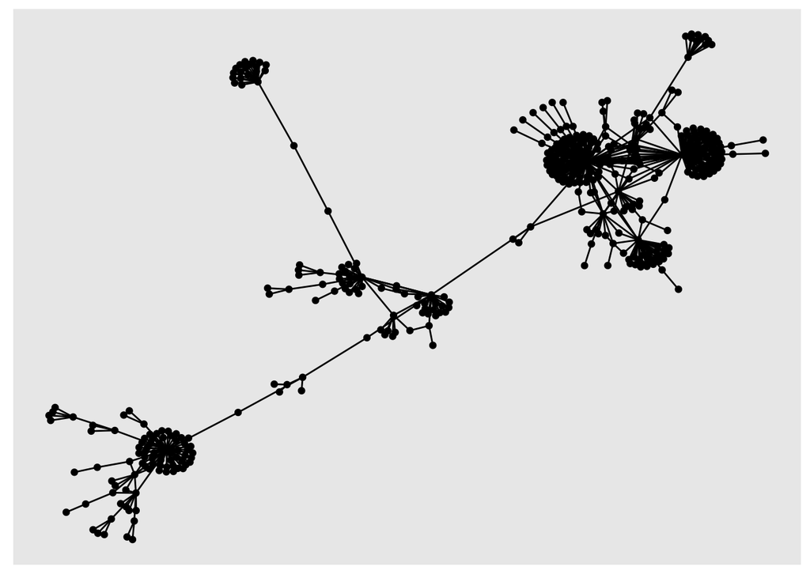

```r
sample_tbl_graph %>% ggraph('nicely') + geom_node_point() + geom_edge_link()
```

You can use the dplyr pipes to perform calculations, filter the data and then visualise it, all in one go:

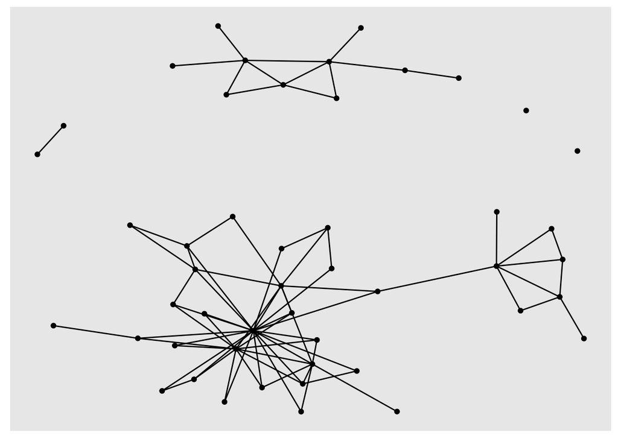

```r
sample_tbl_graph %>%
  activate(nodes)%>%
  mutate(degree = centrality_degree(mode = 'total')) %>%
  filter(degree >2) %>%
  ggraph('nicely') +
  geom_node_point() +
  geom_edge_link()
```

`geom_node_point()` and `geom_edge_link` take aesthetics, just like regular ggplot geoms. You can calculate degree scores and then set the size of the nodes to the result:

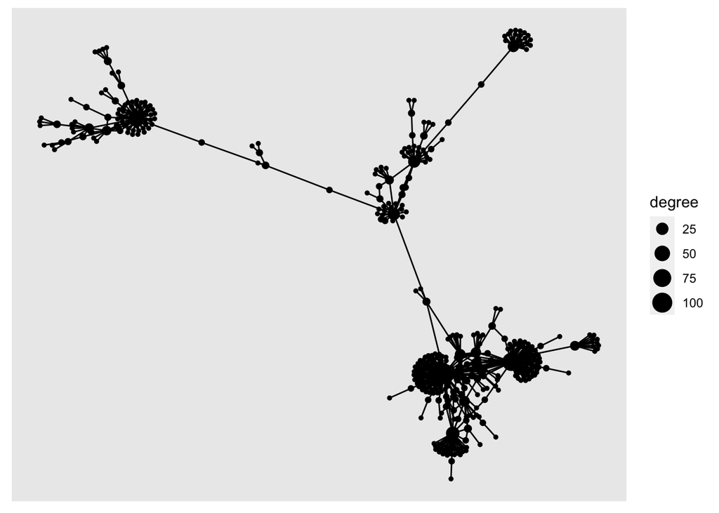

```r
sample_tbl_graph %>%
  activate(nodes)%>%
  mutate(degree = centrality_degree(mode = 'total'))  %>%
  ggraph('nicely') +
  geom_node_point(aes(size = degree)) +
  geom_edge_link()
```

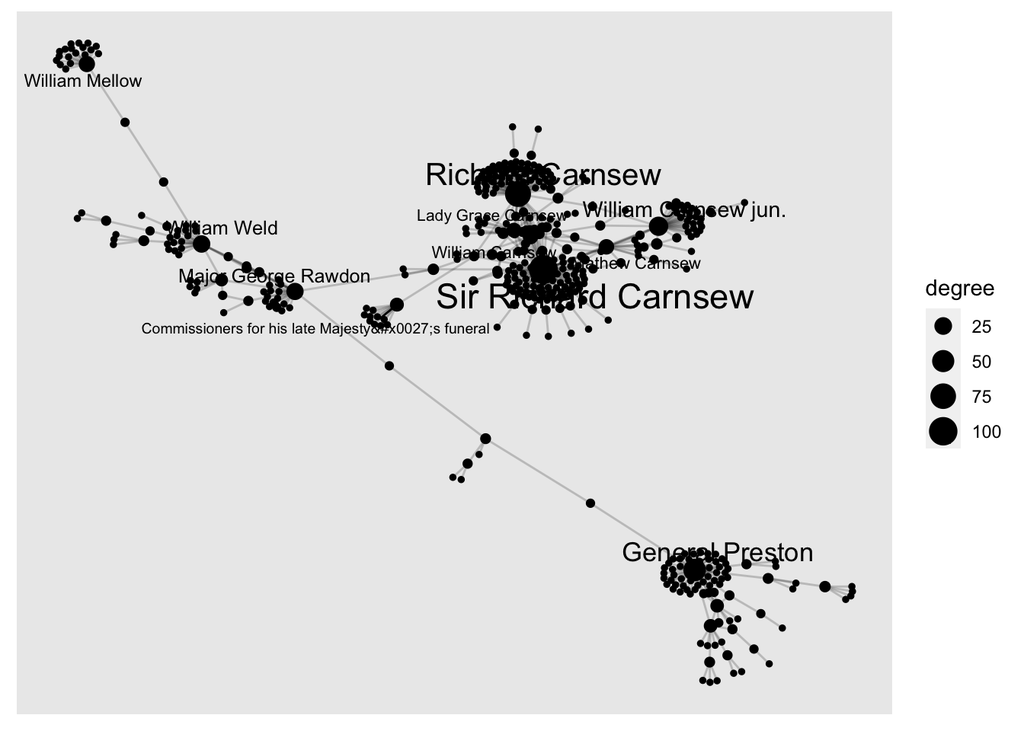

```r
sample_tbl_graph %>%
  activate(nodes)%>%
  mutate(degree = centrality_degree(mode = 'total'))  %>%
  ggraph('nicely') +
  geom_node_point(aes(size = degree)) +
  geom_node_text(aes(label = if_else(degree >10, name, NULL), size = degree), repel = TRUE) +
  geom_edge_link(alpha = .2)
```

## Visualising further information (using extra information with joins)